# **Black-Scholes-Merton (BSM) Model For Options Pricing**

This project comes in 2 parts, first, I study the derivation and assumptions of the Black-Scholes-Merton model and attempt a very basic python implementation of this model.

Then, I explore and understand the issue of volatility, consider potential solutions to this issue, and provide some sort of compromise to continue using the model. I aim to then explore and relax a few underlying assumptions and use some analysis to create a better, more real-world applicable framework

## **Deriving the BSM Model**

### *History and Principles*

The BSM model was first conceived in 1973 by [[Black, Scholes]](https://www.jstor.org/stable/1831029), and independently mathematically analysed and seperately derived by [[Merton]](https://www.jstor.org/stable/3003143) the same year.

Black and Scholes were unconvinced by previous attempts to find formulae to price options. The note that all previous formulae and models rely on arbitrary unpredictable variables - thus making the models effectively useless for instantaneous pricing.

Thus, the Black-Scholes-Merton model uses the following 6 parameters to model the state of financial markets and predict a fair price for options, without any unpredictable parameters that cannot be estimated:

- Volatility
- Price of the underlying asset
- Strike price of the option
- Time until the expiration of the option in years
- Risk-free interest rate
- Type of option (Call or Put)

To derive the Black-Scholes formula, however, we need some understanding of Wiener processes, or random walks first.

A variable, z, is said to follow a Wiener process if it has the following 2 properties:

- The change $\Delta z$ in a time period $\Delta t$ is given by $$\Delta z = \varepsilon \sqrt{\Delta t}$$ Where $\varepsilon$ has $\Phi(0,1)$ distribution
- The values of $\Delta z$ for any two different short periods of time, $\Delta t$, are independent.

So, from the first property, it follows that $\Delta z$ is normally distributed with:

- Mean of $\Delta z$ = 0
- Variance of $\Delta z$ = ${\Delta t}$
- Standard Deviation of $\Delta z$ = $\sqrt{\Delta t}$

And from the second property, we have that $z$ follows a *Markov process* (a stochastic process where future values depend only on the current state, and not on any past states).

Now, in calculus, we move from discrete, small changes to infinitesimal changes, i.e. $\text dx = a \text dt$ is used to indicate that $\Delta x = a \Delta t$ in the limit $\Delta t \rightarrow 0$

Similarly, in stochastic calculus, when referring to $\text dz$ as a Wiener process, it simply means the above properties hold for $\Delta t \rightarrow 0$.

The average change per unit time for a stochastic process is known as the drift rate and the variance per unit time is known as the variance rate.

Now since $\Delta z$ has mean $0$ and variance $\Delta t$, we have that for unit time, mean (drift rate) is $0$ and variance (variance rate) is $1$, as then we have that over a time period $T$, we have expected value of $0$ and variance $T$.

Now, we will state the following and walk through what it means. For a variable $x$, we can define a generalised Wiener process in terms of $\text dz$ as: $$ \text dx = a \ \text dt + b \ \text dz $$ with $a,b\in\mathbb R$.

Now, the $a\ \text dt$ term implies $x$ has drift rate $a$ (as $\text dz$ has $0$ drift rate). Now, without $b\ \text dz$, we can simply integrate and get: $$ \dfrac{\text dx}{\text dt} = a $$ and so: $$ x = x_0 + at $$ where $x_0$ is the value of $x$ at $t=0$.

So, in a period of time, $T$, we get that $x$ increases by $a \ T$. So now, we can think of $b \ \text dz$ as adding variability to the path of $x$, the amount of which is $b$ times a Wiener process.

Now, we note that in discrete terms: $$ \Delta x = a \ \Delta t + b\varepsilon \ \sqrt{\Delta t} $$ So:

- Mean of $\Delta x$ = $a \ \Delta t$
- Variance of $\Delta x$ = $b^2\Delta t$
- Standard Deviation of $\Delta x$ = $b\sqrt{\Delta t}$

Now, it may be useful to plot the idea of a generalised Wiener process to get an idea of what the process really means.

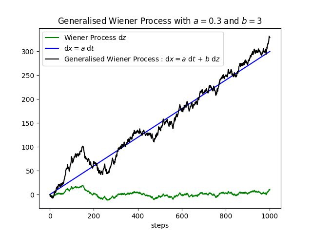

```python
%matplotlib widget

"""
Generalised Wiener Processes in Python
"""

# Imports
import matplotlib.pyplot as plt
import numpy as np

# Setting our constants
a = 0.3
b = 3

# We'll store our values of x in an array
xs = np.zeros(1000)

# Now, we'll use discrete time jumps of 1 to approximate the process. We'll use 1000 time jumps
T = 1000
ts = np.arange(1, 1001, 1)

# We need epsilon as standard normal variable samples
epsi = np.random.standard_normal(T-1)

# Now we simply get the values for the drift rate
aT = a * np.arange(1, 1001, 1)

# Now, we'll calculate the values of each z and calculate values for x
zs = np.zeros(T)
temp = 0

for i in range(T-1):
    temp += epsi[i]
    zs[i+1] = temp
    xs[i+1] = aT[i+1] + b * zs[i+1]

# Plotting
fig = plt.figure()
ax = fig.add_subplot()

ax.plot(ts,zs, color = "green", label = "Wiener Process d$z$")
ax.plot(ts, aT, color = "blue", label = "d$x = a$ d$t$")
ax.plot(ts, xs, color = "black", label = "Generalised Wiener Process : d$x = a$ d$t$ + $b$ d$z$")
ax.set_xlabel("steps")
ax.set_title(f"Generalised Wiener Process with $a = {a}$ and $b = {b}$")
ax.legend()
plt.show()
```

As we can see, the Generalised Wiener process is formed of the general trend line, and some additional noise.

### *Stock Price Process*

In order to derive the BSM equation, we assume "ideal conditions" of the market for both the stock and the option:

1. The short term interest rate is known and constant.
2. The stock price follows a random walk in continuous time with variance rate proportional to the square of the stock price. Thus, the distribution of possible stock prices at the end of any finite interval of time is log-normal. The variance rate of the return on the stock is constant.
3. The stock pays no dividends or other distributions.
4. The option is European (can only be exercised at maturity).
5. No transaction costs for either stocks or options.
6. It is possible to borrow any fraction of the price of a security to buy it or to hold it, at the short-term interest rate. (Allows for modelling portfolio value with smooth differential equations, as securities trading is now continuous)
7. There are no penalties to short selling. (Gives frictionless markets - no barriers to any types of trading)
8. There are no riskless arbitrage opportunities.

We will return to these assumptions later to challenge them, but for now let us hold them as they are.

It is also tempting to model stock price as having constant drift, but this isn't quite right - the expected percentage return by investors is indepenedent of price of the stock. Suppose investors require 14% annual expected return on a stock priced £10. Well then, they also require 14% annual expected return when the stock is priced £50 - which are different actual values.

Thus, we instead take expected return as constant. This means that in a small interval of time $\Delta t$, we expect increase in $S$ of $S\mu \ \Delta t$, so: $$ \Delta S = S\mu \ \Delta t $$ Now, as has become standard for us, as $\Delta t \rightarrow 0$: $$ \text dS = S\mu \ \text dt $$ So: $$ \dfrac{\text dS}{S} = \mu \ \text dt $$ and integrating with limits 0 and $T$: $$ S_T = S_0e^{\mu T} $$ With $S_T$ and $S_0$ being price at $T$ and $0$

This demonstrates that when we have no uncertainty, we expect continuous, compounded growth of $\mu$ per unit time.

In practice we have uncertainty though. One of our assumptions is that "the variance rate of the return on the stock is constant" and "variance rate proportional to the square of the stock price." This indicates we have an $\sigma S \ \text dz$ term (where $\sigma$ is percentage uncertainty or percentage volatility), but let's unpack this a bit. Essentially, this states that the investors' uncertainty is independent of price, i.e. an investor is equally uncertain of the result when priced at £10 or £50. This makes sense intuitively.

Thus, we have the following process for stock prices, a process called Geometric Brownian Motion: $$ \text dS = \mu S \ \text dt + \sigma S \ \text dz $$ Note that this has the fairly trivial solution $S = \exp{(\mu t + \sigma \text dz)}$ - although we will not focus on this too much.

Now, just for a visual, let us plot the naiively predicted price of a theoretical stock at constant $\mu$ but varying $\sigma$.

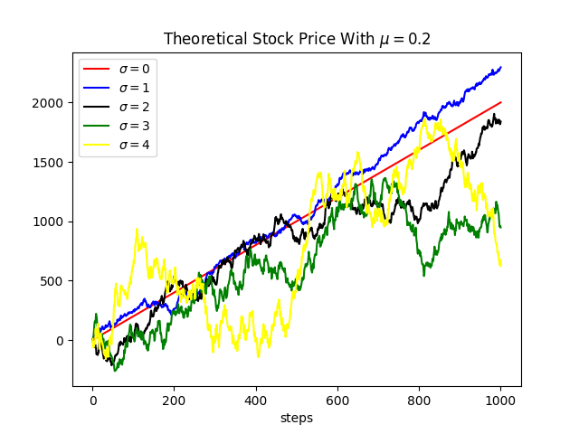

```python
"""
Theoretical Stock Price
"""

# Imports
import matplotlib.pyplot as plt
import numpy as np

# Setting our constants
mu = 0.2
sigma = [0, 1, 2, 3, 4]
colors = ["red", "blue", "black", "green", "yellow"]

# We'll store our values of x in an array
xs = np.zeros(1000)

# Say we start at price 10
xs[0] = 10

# Now, we'll use discrete time jumps of 1 to approximate the process. We'll use 1000 time jumps
T = 1000
ts = np.arange(1, T+1, 1)

# Now we simply get the values for the drift rate
aT = mu * np.arange(1, 1001, 1)

# Plotting
fig = plt.figure()
ax = fig.add_subplot()

# Now, we'll calculate the values of each z and calculate values for x
zs = np.zeros(T)

for s in sigma:
    epsi = np.random.standard_normal(T-1)
    temp = 0
    for i in range(T-1):
        temp += epsi[i]
        zs[i+1] = temp
        xs[i+1] = xs[0] * aT[i+1] + s * xs[0] * zs[i+1]
    ax.plot(ts, xs, label = f"$\sigma = {s}$", color = colors[sigma.index(s)])

ax.set_xlabel("steps")
ax.set_title(f"Theoretical Stock Price With $\mu = {mu}$")
ax.legend()
plt.show()
```

### *Deriving and Solving the BSM Differential Equation*

Now, before deriving the BSM Equation, we'll touch on the key idea underlying the model.

The general gist is that we can set up a riskless portfolio consisting of a position in the derivative and a position in the stock. With the assumptions leading to absence of arbitrage opportunities, the return from the portfolio must be the risk-free interest rate, r. Now, by setting it up in such a fashion, we can remove the dependence on a Wiener process and so, the value of the portfolio after any short time period will be known. Importantly, the time period must be short - as we will soon discuss.

First we can always make our riskless portfolio as both options and stocks rely on the same underlying asset, and have the same source of uncertainty - stock price movement. Thus, in the correctly calibrated portfolio, gains/losses from stock price will always be offset by losses/gains from derivative value.

Now, the reason this only holds on small time periods is that in any non-small periods of time, the exact relation between derivative and stock prices may change, not allowing the offset as we have calibrated.

Now, let us begin the derivation.

First, recall the stock price process: $$ \text dS = \mu S \ \text dt + \sigma S \ \text dz $$ Now, let $f$ be the price of a call or put stock option. By Ito's Lemma (see addendum) since $f$ must be some function of stock price $S$ and time $t$: $$ \text df = \left(\dfrac{\partial f}{\partial t} + \mu S \dfrac{\partial f}{\partial S} + \dfrac{\sigma^2S^2}{2}\dfrac{\partial^2 f}{\partial S^2}\right)\text dt + \sigma S\dfrac{\partial f}{\partial S} \ \text dz $$ Which in discrete terms is: $$ \Delta S = \mu S \ \Delta t + \sigma S \ \Delta z $$ $$ \Delta f = \left(\dfrac{\partial f}{\partial t} + \mu S \dfrac{\partial f}{\partial S} + \dfrac{\sigma^2S^2}{2}\dfrac{\partial^2 f}{\partial S^2}\right)\Delta t + \sigma S\dfrac{\partial f}{\partial S} \ \Delta z $$ Now, let's create our risk-free portfolio. Consider a portfolio valued $\Pi$. We want to eliminate risk, which comes with our Wiener variable, so, we need to balance our stock and option purchases in such a way.

This is done by buying $-1$ derivative and $+\frac{\partial f}{\partial S}$ shares. We can see this once we expand our equations: $$ \Pi = -f + \dfrac{\partial f}{\partial S}S $$ Thus, we consider now $\Delta \Pi$ as: $$ \Delta \Pi = -\Delta f + \dfrac{\partial f}{\partial S}\Delta S $$ $$ \Delta \Pi = -\left(\dfrac{\partial f}{\partial t} + \mu S \dfrac{\partial f}{\partial S} + \dfrac{\sigma^2S^2}{2}\dfrac{\partial^2 f}{\partial S^2}\right)\Delta t + \mu S \dfrac{\partial f}{\partial S} \ \Delta t $$ $$ \Delta \Pi = -\left(\dfrac{\partial f}{\partial t} + \dfrac{\sigma^2S^2}{2}\dfrac{\partial^2 f}{\partial S^2}\right)\Delta t $$

Now, because this doesn't include $\Delta z$, it is riskless over $\Delta t$. Now, one of our assumptions is that "It is possible to borrow any fraction of the price of a security to buy it or to hold it, at the short-term interest rate." Now, we will demonstrate that our portfolio must earn the same rate of return as the risk-free interest rate. If it earned less, an arbitrageur could short the portfolio and buy risk-free securities. If it earned more, they could borrow money to buy the portfolio. Both of these offer risk-free earnings. So, we impose that: $$ \Delta \Pi = r\Pi \ \Delta t $$ With $r$ our risk-free interest rate. Now, we substitute: $$ \left(\dfrac{\partial f}{\partial t} + \dfrac{\sigma^2S^2}{2}\dfrac{\partial^2 f}{\partial S^2}\right)\Delta t = r\left(f - \dfrac{\partial f}{\partial S}S\right) \ \Delta t $$ And so, we get the Black-Scholes PDE: $$ \dfrac{\partial f}{\partial t} + rS\dfrac{\partial f}{\partial S} +\dfrac{\sigma^2S^2}{2}\dfrac{\partial^2 f}{\partial S^2} = rf $$

Being a partial differential equation, solutions are hard to compute, taking pages of work. So here, we will just look at the Black-Scholes-Merton formula as a solution to the equation.

Now, the solution we are about to discuss emerges on the following conditions:

- $C = \max{\{S-K, 0\}}$ when $t=T$ when call option.
- $C(S,T) = \max{\{K-S,0\}}$ when put option. Which are simple results of call options. Now, the solution is: $$ c = S_0 N(d_+) - Ke^{-rT}N(d_-) $$ $$ d_+ = \dfrac{1}{\sigma\sqrt T}\left(\ln\left(\dfrac{S_0}K\right) + \left(r + \dfrac{\sigma^2}{2}\right)T\right) $$ $$ d_- = d_+ - \sigma\sqrt{T} $$

And, by put-call parity (see addendum) with our discount factor $e^{-r(T)}$: $$ p = Ke^{-rT}N(-d_-) - S_0 N(-d_+) $$ These form the BSM model, as we will implement shortly.

## **Implementing the BSM Model in Python**

Initially, we'll define the functions for put and call options.

```python
"""
The BSM Model in Python
"""

#Imports
import numpy as np
import scipy as sc
import matplotlib.pyplot as plt

#Defining the Normal Cumulative Distribution Function as N
N = sc.stats.norm.cdf

#Defining functions for Call and Put options
def CALL(S, K, T, r, sigma):
    d1 = (np.log(S/K) + (r+(sigma**2)/2)*T) / (sigma*np.sqrt(T)) #This is d+ for CALL options
    d2 = d1 - sigma*np.sqrt(T) #This is d- for CALL options
    return S*N(d1)-K*np.exp(-r*T)*N(d2) #This is the formula for CALL options

def PUT(S, K, T, r, sigma):
    d1 = (np.log(S/K) + (r+(sigma**2)/2)*T) / (sigma*np.sqrt(T)) #This is d+ for PUT options
    d2 = d1 - sigma*np.sqrt(T) #This is d- for PUT options
    return -S*N(-d1)+K*np.exp(-r*T)*N(-d2) #This is the formula for PUT options
```

We can now see what happens as we vary constants and variables.

### *S effect on Options Value*

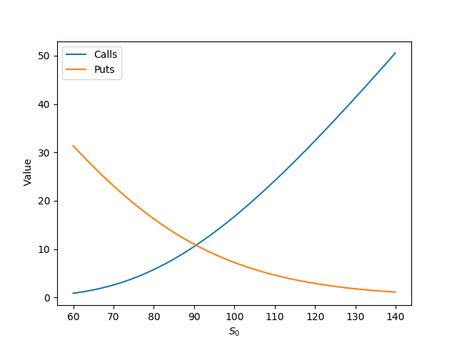

```python
S = np.arange(60,140,0.1)
K = 100
T = 1
r = 0.1
sigma = 0.3
# Assigning Variables and setting the variable whose change we are interested in be set to a range

calls = [CALL(s,K,T,r,sigma) for s in S]
puts = [PUT(s,K,T,r,sigma) for s in S]
# We find a list of calculated values of calls and puts

# Plotting
fig = plt.figure()
ax = fig.add_subplot()

ax.plot(S, calls, label='Calls')
ax.plot(S, puts, label='Puts')
ax.set_xlabel('$S_0$')
ax.set_ylabel(' Value')
ax.legend()
plt.show()
```

This is what is expected, we know that at maturation, the return is based on the difference between strike price and asset price. So, if the initial value of the underlying asset is significantly higher than the strike price, its very likely that the return on a call option will be greater than 0,and vice versa for put options.

Thus, the option's price should be higher below $K$ and lower above $K$ for puts (as when lower, the expected result is in the money, and above, expected result is not in the money), and the opposite for calls.

Thus, this graph is expected.

### *$\sigma$ effect on Black-Scholes Value*

As expected, when volatility is increased, both call and put options increase in value in what seems to be a linear fashion. This seems to make sense, as we'd want the options pricing to be greater when the future is more uncertain.

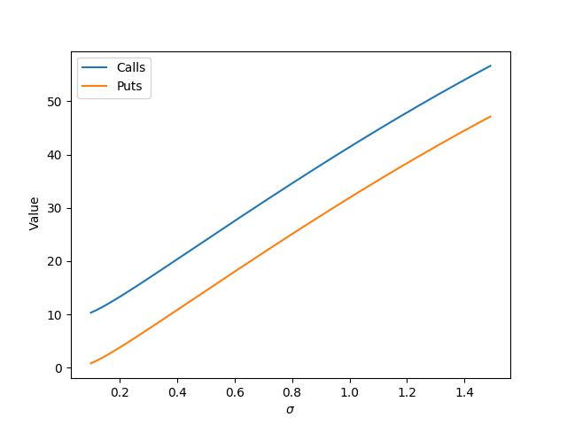

```python
S = 100
K = 100
T = 1
r = 0.1
sigmas = np.arange(0.1,1.5,0.01)

calls = [CALL(S,K,T,r,s) for s in sigmas]
puts = [PUT(S,K,T,r,s) for s in sigmas]

fig = plt.figure()
ax = fig.add_subplot()


ax.plot(sigmas, calls, label='Calls')
ax.plot(sigmas, puts, label='Puts')
ax.set_xlabel('$\sigma$')
ax.set_ylabel(' Value')
ax.legend()
plt.show()
```

To see why calls seems to be valued above puts for all volatilities, let us vary the interest.

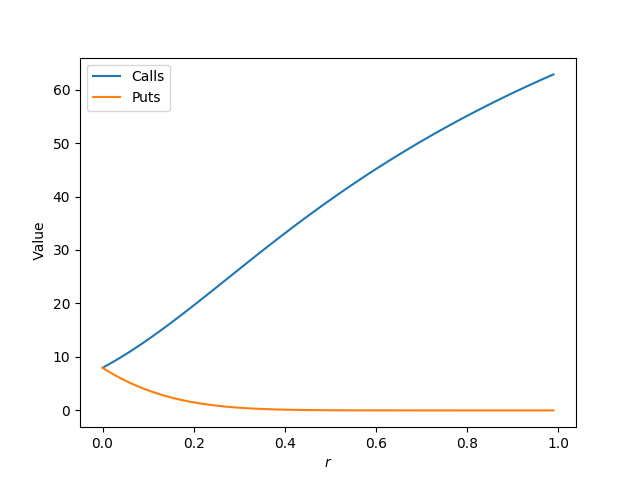

```python
S = 100
K = 100
T = 1
rs = np.arange(0,1,0.01)
sigma = 0.2
calls = [CALL(S,K,T,R,sigma) for R in rs]
puts = [PUT(S,K,T,R,sigma) for R in rs]

fig = plt.figure()
ax = fig.add_subplot()

ax.plot(rs, calls, label='Calls')
ax.plot(rs, puts, label='Puts')
ax.set_xlabel('$r$')
ax.set_ylabel(' Value')
plt.legend()
plt.show()
```

So, we deduce that increasing interest rates increases the valuation of call options, and decreases the valuation of put options.

This makes sense, as higher interest means more valuation of the non-risky asset, so less chance of the result being not in the money.

### *Effects of Time on Black-Scholes Prices*

We know that when $T$ is small, the uncertainity of the future is low, so the options price should reflect this, with call and put options being valued at similar values.

But when $T$ increases, the valuation of put and calls spread apart, since the uncertainty brings risk, so the fair price for put/call options spread apart.

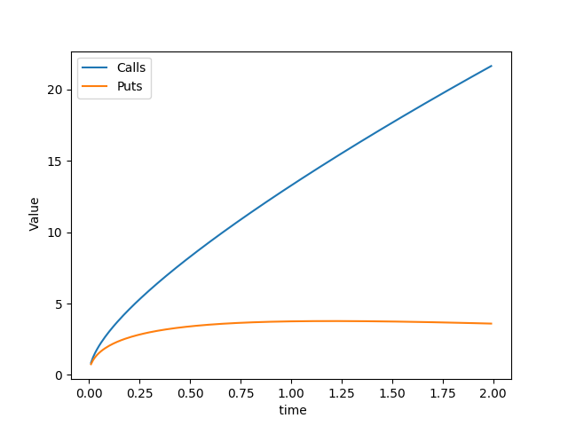

```python
S = 100
K = 100
Ts = np.arange(0.01,2,0.01)
r = 0.1
sigma = 0.2
calls = [CALL(S,K,t,r,sigma) for t in Ts]
puts = [PUT(S,K,t,r,sigma) for t in Ts]

fig = plt.figure()
ax = fig.add_subplot()

ax.plot(Ts, calls, label='Calls')
ax.plot(Ts, puts, label='Puts')
ax.set_xlabel(' time')
ax.set_ylabel(' Value')
plt.legend()
plt.show()
```

As time increases, the probability of being in the money for call options increases, as the interest rate adds to the value of the non-risky asset, and uncertainty benefits the options holder, so to maintain fair prices, the prices rise.

## **The Issue(s) of Volatility**

The Black-Scholes-Merton model has many benefits, one of which, being the nature of the parameters used in its formulation. Almost every variable we consider is something that can be immediately known or estimated from other empirical means. The only variable that doesn't necessarily have an easy way of calculating it is *volatility*. Since future volatility needs to be known, our best options are to estimate it using some methods

Here we can look at an example

```
Standard Deviation across whole:  0.283
```

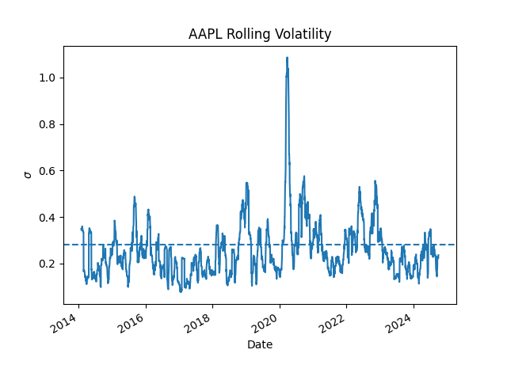

```python
"""
AAPL Volatility Case Study
"""

# Imports
import yfinance as yahooFinance
import pandas as pd
import datetime as dt

# We set the ticker as the yahoo finance code for a certain stock or asset, in this case, AAPL for Apple
ticker = yahooFinance.Ticker("AAPL")

start_date = dt.datetime(2014,1,1)
end_date = dt.datetime(2024,10,1)
# We set the start and end dates of the period we are interested in

data = ticker.history(start=start_date,end=end_date)
# We now pull from Yahoo the historical price data for Apple between the specified start and end date

values = data["Close"]
# We are interested in the price at change.

change = values.pct_change()
# We want the percentage change between values to calculate volatility.

rolling_sigma = change.rolling(20).std() * np.sqrt(255)
# We caclulate the rolling volatility over time periods

sigma = np.std(change)*np.sqrt(255)
# We calculate the total volatility over the whole time period

# Plotting
fig = plt.figure()
ax = fig.add_subplot()

rolling_sigma.plot()
ax.set_ylabel('$\sigma$')
ax.set_title('AAPL Rolling Volatility')
plt.axhline(y = sigma, linestyle = '--')
print("Standard Deviation across whole: ", round(sigma,3))
```

In the historical case of Apple, the annual volatility given for the time period 2014 - 2024 is given as $0.283$, but this is obviously not constant, and the BSM model does not account for the unexpected spike in volatility in 2020.

So the neccessity of future knowledge of volatility is a big, glaring issue with the BSM model as presented in its most barebones, essential form, and we need some ways to estimate/resolve this.

### *Implied Volatility*

First, we'll use *implied volatility*, calculated by back-solving the BSM model for a specific asset with market information about issued contracts - this way, we get an idea of "instantaneous volatility", or, we estimate what the market believes volatility to be.

So, we need to make functions for inverse solving the BSM for call and put options.

We want to use some form of inverse BSM equation to calculate our sigmas. Let this function be $f$. Then, using our provided option ask price, $C$, consider the following: $$ f(\sigma) - C = 0 $$ It's evident that solving this for $\sigma$ gives us our implied volatility.

Now, evidently, the BSM equation doesn't have a neat inverse, but we can use numerical methods to estimate solutions. Here, we wil use scipy's `minimize_scalar` which uses Brent's method. I chose arbitrary bounds of (0.000001, 5), since a volatility of 0 causes a divide-by-0 error:

```python
"""
Inverse BSM Solvers
"""

# Imports
from scipy import optimize as op

# We define 2 functions to calculate implied volatility by backsolving the BSM Formula with root-finding by Brent's method

def ImpVolC(C,S,K,t,r):

    def BSMCallRoot(sigma):
        return((CALL(S, K, t, r, sigma) - C))

    # Implement the solver
    sig = op.minimize_scalar(BSMCallRoot, bounds = (0.000001, 5), method='bounded')

    return float(sig.x)

# The same principle applies for the put options

def ImpVolP(C,S,K,t,r):

    def BSMPutRoot(sigma):
        return((PUT(S, K, t, r, sigma) - C))

    # Implement the solver
    sig = op.minimize_scalar(BSMPutRoot, bounds = (0.000001, 5), method='bounded')

    return float(sig.x)
```

Now, let's pull some historic data. Consider MSFT's nearest option contracts and current price:

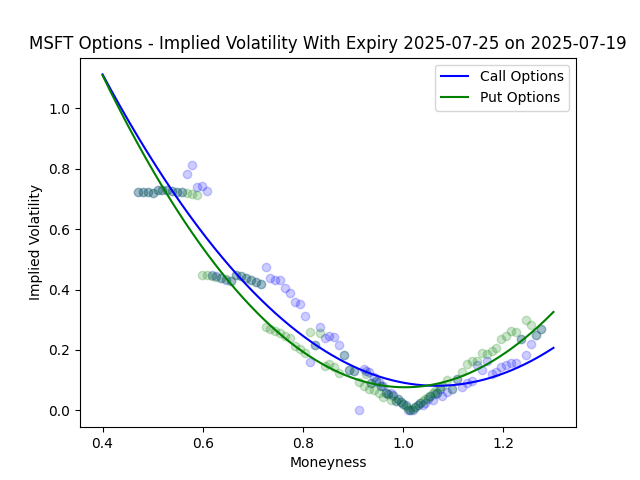

```python
"""
Plotting MSFT Volatility smiles
"""

# Imports
from curl_cffi import requests
import yfinance as yf
import numpy as np
import matplotlib.pyplot as plt
from datetime import date as dt

#Function to get midpoint of ask and bid price - this makes the model slightly better as it's more realistic
def get_mid(data):
    return 0.5 * (float(data["a"]) + float(data["b"])) if data["a"] and data["b"] else float(data["a"])


# Pull option prices from "www.optionsprofitcalculator.com"
msft = requests.get("https://www.optionsprofitcalculator.com/ajax/getOptions?stock=MSFT&reqId=1", impersonate="chrome").json()["options"]
key = list(msft.keys())[1]
dataC = msft[key]["c"]
dataP = msft[key]["p"]

# Now, we back-solve, since we're considering theoretically European Stock Options, we'll use the €STR as a proxy for risk-free interest - this isn't annualised, but it's close enough
# We take the current stock value from yfinance, and pull the strike prices from "www.optionsprofitcalculator.com"

S = float(yf.Ticker("MSFT").history(period = "1d")["Close"].iloc[0])
t = 3 / 365.25
r = float(requests.get("https://api.estr.dev/latest", impersonate = "chrome").json()["value"]) #From the €STR
Ks = list(dataC.keys())

sigmasC = np.array([ImpVolC(get_mid(dataC[k]), S, float(k), t, r) for k in Ks])
sigmasP = np.array([ImpVolP(get_mid(dataP[k]), S, float(k), t, r) for k in Ks])

Ks = np.array([float(k) for k in Ks])

# Calculate moneyness
M = Ks/S

# Quadratic Interpolation for smoothness
modelC = np.poly1d(np.polyfit(M, sigmasC, 2))
lineC = np.linspace(0.4, 1.3, 1000)

modelP = np.poly1d(np.polyfit(M, sigmasP, 2))
lineP = np.linspace(0.4, 1.3, 1000)

fig = plt.figure()
ax = fig.add_subplot()

# Now, let us plot sigmas and Ks
ax.scatter(M, sigmasC, color = "blue", alpha = 0.2)
ax.plot(lineC, modelC(lineC), color = "blue", label = "Call Options")
ax.scatter(M, sigmasP, color = "green", alpha = 0.2)
ax.plot(lineP, modelP(lineP), color = "green", label = "Put Options")
ax.set_xlabel("Moneyness")
ax.set_ylabel("Implied Volatility")
ax.set_title(f"MSFT Options - Implied Volatility With Expiry {str(key)} on {str(dt.today())}")
ax.legend()
plt.show()
```

Wonderful! We see that our calculated implied volatilities for both puts and calls are very similar! This is exactly what we expect; volatility should not change for different option types.

To see this, first consider the put-call parity: $$ C(t) - P(t) = S(t) - K\cdot B(t,T) $$

Now, we simply plug in our BSM calculations for $C$ and $P$ $$ N(d_+^{\text{Call}})S(t) - N(d_-^{\text{Call}})Ke^{-r(T-t)} - N(-d_-^{\text{Put}})Ke^{-r(T-t)} - N(-d_+^{\text{Put}})S(t) = S(t) - K\cdot B(t,T) $$ Now, $e^{-r(T-t)}$ is the discount factor, so: $$ S(t)[N(d_+^{\text{Call}}) - N(-d_+^{\text{Put}})] - K\cdot B(t,T)[N(d_-^{\text{Call}}) - N(-d_-^{\text{Put}})] = S(t) - K\cdot B(t,T) $$

Now, we need $N(d_+^{\text{Call}}) - N(-d_+^{\text{Put}}) = 1$ and $N(d_-^{\text{Call}}) - N(-d_-^{\text{Put}}) = 1$ which occurs iff $d_+^{\text{Call}} = d_+^{\text{Put}}$ and $d_-^{\text{Call}} = d_-^{\text{Put}}$.

Now, note that put and call options in this scenario necessarily share current price, strike price, current time, discount factor, and time to maturity. So, the only free variable is (implied) volatility. But since $d_+^{\text{Call}} = d_+^{\text{Put}}$ and $d_-^{\text{Call}} = d_-^{\text{Put}}$, we must have that implied volatility is equal for both puts and calls.

Now, this block of code used data from just one expiration time to calculate this. It would be more useful to have a look at volatility changing as time changes.

We can use the same sort of framework to accomplish this, so, we will make a *volatility surface*, using just calls in our calculations, as puts are (more-or-less) the same.

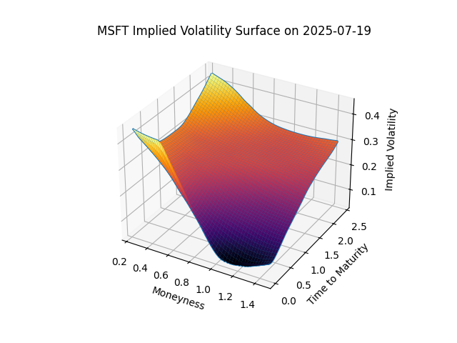

```python
"""
Plotting an Implied Volatility Surface
"""

# Imports
import numpy as np
from datetime import datetime as dt
from datetime import date as dat
from curl_cffi import requests
import yfinance as yf
import matplotlib.pyplot as plt
from matplotlib import cm
import scipy as sp

# Initialising the figure for plotting
fig = plt.figure()
ax = fig.add_subplot(projection = "3d")

# Pulling option prices from "www.optionsprofitcalculator.com"
msft = requests.get("https://www.optionsprofitcalculator.com/ajax/getOptions?stock=MSFT&reqId=1", impersonate="chrome")
data = msft.json()["options"]

# Now, we need our t variable to consist of the number of days between now and expiry - we set this up here
now = dt.today()
date_format = "%Y-%m-%d"
ts = []

# Now, we back-solve, since we're considering theoretically European Stock Options, we'll use the €STR as a proxy for risk-free interest
# We take the current stock value from YahooFinance, and pull the strike prices from the "data" json variable

S = float(yf.Ticker("MSFT").history(period = "1d")["Close"].iloc[0])
r = float(requests.get("https://api.estr.dev/latest", impersonate = "chrome").json()["value"]) #From the €STR
Ks = []
sigmas = []

# Here, we do a LOT of the work for this. We first get the date of expiry from our "data" variable, use our root finding approach to get an implied volatility,
# and append values of strike price, time and sigmas to lists for later plotting.

for i in list(data.keys())[1:]: # Using every value but the closest to prevent weird results by considering options very close to expiry
    for k in list(data[i]["c"].keys()):
        t = (dt.strptime(i, date_format) - now).days / 365.25
        sigma = ImpVolC(get_mid(data[i]["c"][k]), S, float(k), t, r)
        Ks.append(float(k))
        sigmas.append(sigma)
        ts.append(t)

# Convert our lists to np arrays
ts = np.array(ts)
Ks = np.array(Ks)
sigmas = np.array(sigmas)

# Calculate moneyness as a decimal
M = (Ks / S)

# Now, we'll interpolate for smoothness of our surface
# First, we set up an evenly distributed linear space of moneyness and time

M_plot = np.linspace(min(M), max(M), 200)
t_plot = np.linspace(min(ts), max(ts), 200)

# Then, we create our meshgrid, and an array of zeroes for our predicted z-axis (sigma) values to be assigned to
x, y = np.meshgrid(M_plot, t_plot, indexing = "xy")
Z = np.zeros((M.size, sigmas.size))

# We create our model here, using radial basis linear interpolation, and then predict our z-axis (sigma) values
spline = sp.interpolate.Rbf(M,ts,sigmas,function='linear', smooth = 5)

Z = spline(x, y)

# Now, let us plot our predicted sigmas, Ks and times, and create our surface
ax.plot_wireframe(x, y, Z)
ax.plot_surface(x, y, Z, cmap = cm.inferno)

# Labelling
ax.set_xlabel("Moneyness")
ax.set_ylabel("Time to Maturity")
ax.set_zlabel("Implied Volatility")
ax.set_title(f"MSFT Implied Volatility Surface on {str(dat.today())}")

# Show plot
plt.show()
```

Now, we have an estimator for volatility for our model! Great, it seems we have found a nice way to avoid some of the issues of volatility.

Okay, but we have some other introduced problems. For one, we've used close-to-close prices of the stock in our estimate. This is *fine* but for any practical purpose, this sort of discrepancy introduces inaccuracies in larger calculations. We can avoid this by considering open, high, low and close prices, and taking some sort of average of all of them. We may also want to consider better ways of estimating the market's valuation of option contracts, potentially looking at any sales of the contract, and how much it has sold for, to better estimate a contract price.

Another potential thing to consider is that we are calculating volatility *purely* from analysis of data right now, without looking at any historical data. It may be better to look at trends in volatility over history and use that as well to calculate our volatility.

### *The Yang-Zhang Estimator*

This chapter is based on "Drift‐Independent Volatility Estimation Based on High, Low, Open, and Close Prices" by [[Yang, Zhang]](https://www.jstor.org/stable/10.1086/209650)

In order to tackle the close-close price issues above and also consider high, low, open and close prices in their estimation, Yang and Zhang propose the following model which uses a variety of historical data to estimate volatility: $$ V = V_O + kV_C + (1 - k)V_{RS} $$ With: $$ V_O = \dfrac{1}{n-1}\sum^n_{i=1}(o_i - \bar o)^2 $$ $$ V_C = \dfrac{1}{n-1}\sum^n_{i=1}(c_i - \bar c)^2 $$ $$ V_{RS} = \dfrac{1}{n}\sum^n_{i=1}[u_i(u_i-c_i) + d_i(d_i-c_i)] $$ With the following parameters:

- $V$ - Variance ($\sigma^2$)
- $k$ - A constant that determines weighting
- $n$ - Time period (days)
- $c_i$ - Normalised closing price of ith period ($\ln(C_i) - \ln(O_i)$)
- $\bar c$ - Mean normalised closing price
- $o_i$ - Normalised opening price of ith period ($\ln(O_i) - \ln(C_{i-1})$)
- $\bar o$ - Mean normalised opening price
- $u_i$ - Normalised high of ith period ($\ln(H_i) - \ln(O_i)$)
- $d_i$ - Normalised low of ith period ($\ln(L_i) - \ln(O_i)$)

Yang and Zhang also offer the following formula to determine the value of k: $$ k = \dfrac{\alpha - 1}{\alpha +\dfrac{n+1}{n-1}} $$ Where they claim $\alpha = 1.34$ as their most empirically suitable value, which we will also use.

Now $V_O$ and $V_C$ are instantly recognisable as the sample variance for opening and closing prices - so volatility estimated from opening and closing prices. $V_{RS}$ is a little more complicated, as it is actually a different type of volatility estimator described by [[Rogers, Satchell]](https://doi.org/10.1214/aoap/1177005835).

First, let's define high and low of the ith period appropriately. Let $H_t = \sup\{X_u : u\leq t\}$ and $L_t = \inf\{X_u : u\leq t\}$ where $X_t$ is the price of the stock at time $t$.

Then we define the following estimator: $$ \sigma^2_t = S_t(S_t - X_t) + I_t(I_t - X_t) $$ Now since we are working in discrete time periods of days, $X_t$ is just the closing price on day $t$, so: $$ \sigma^2_t = S_t(S_t - c_t) + I_t(I_t - c_t) $$ Now, as demonstrated in Rogers and Satchell's paper, this has the interesting property that: $$ E[S_t(S_t - c_t) + I_t(I_t - c_t)] = \sigma^2t $$ Note that the right hand side has no mention of $\mu$, so we have a "drift-independent" measure of volatility. This is the estimator formulated by Rogers and Satchell, which plays an important role in the Yang-Zhang Estimator.

Now, let us apply an implementation of this in Python to a historical dataset and compare it to a simple rolling average.

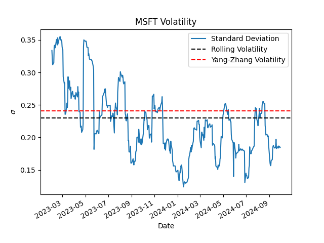

```python
"""
Yang-Zhang Estimator Comparison to Naiive Approach
"""

# Imports
import yfinance as yahooFinance
import numpy as np
import datetime as dt
import matplotlib.pyplot as plt
import pandas as pd

# Creating our YZEstimator Function
def YZEstimate(open, close, high, low , alpha=1.34):
    # Normalising - we slice all arrays since we have normalised open relying on previous open prices, and we want to maintain all arrays are the same size
    c = np.log(close[1:]/open[1:])
    h = np.log(high[1:]/open[1:])
    l = np.log(low[1:]/open[1:])
    o = np.log(open[1:]/close[:-1])

    Vo = o.var()
    Vc = c.var()
    Vrs = (h*(h - c) + l*(l - c)).mean()

    n = len(o)

    k = (alpha-1)/(alpha + (n + 1)/(n - 1))

    return np.sqrt(255 *(Vo + k*Vc + (1-k)*Vrs))

# We set the ticker as the yahoo finance code for a certain stock or asset, in this case, AAPL for Apple
ticker = yahooFinance.Ticker("MSFT")

# We set the start and end dates of the period we are interested in
start_date = dt.datetime(2023,1,1)
end_date = dt.datetime(2024,10,1)

# We now pull from Yahoo the historical price data for MSFT between the specified start and end date
# Usefully, this provides open, close, high and low prices
data = ticker.history(start=start_date,end=end_date)

# We want the percentage change between closing values to calculate volatility.
change = data["Close"].pct_change()

# We caclulate the rolling volatility over our time periods
rolling_sigma = change.rolling(20).std() * np.sqrt(255)

sigma = np.std(change)*np.sqrt(255)
# We calculate the total volatility over the whole time period

# Now, we will use the YZ estimator
open = pd.DataFrame(data["Open"]).to_numpy().flatten()
close = pd.DataFrame(data["Close"]).to_numpy().flatten()
high = pd.DataFrame(data["High"]).to_numpy().flatten()
low = pd.DataFrame(data["Low"]).to_numpy().flatten()

sigmaYZ = YZEstimate(open, close, high, low)

# Plotting
fig = plt.figure()
ax = fig.add_subplot()

rolling_sigma.plot(label = "Standard Deviation")
ax.plot
ax.set_ylabel('$\sigma$')
ax.set_title('MSFT Volatility')
plt.axhline(y = sigma, linestyle = '--', color = "black", label = "Rolling Volatility")
plt.axhline(y = sigmaYZ, linestyle = '--', color = "red", label = "Yang-Zhang Volatility")
ax.legend()
plt.show()
```

This by itself provides us with very little, so let's look at different time frames:

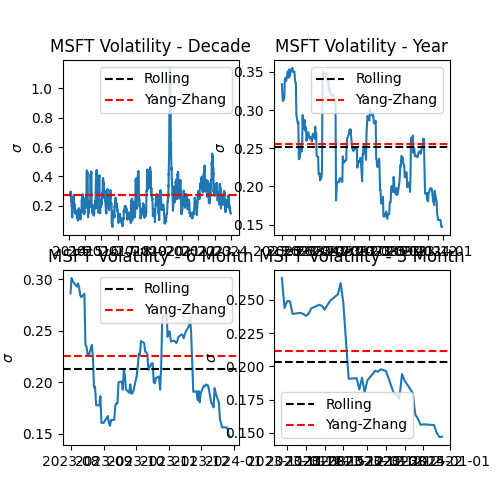

```python
ticker = yahooFinance.Ticker("MSFT")

def get_data(start, end):
    data = ticker.history(start=start,end=end)

    change = data["Close"].pct_change()

    rolling_sigma = change.rolling(20).std() * np.sqrt(255)

    sigma = np.std(change)*np.sqrt(255)

    open = pd.DataFrame(data["Open"]).to_numpy().flatten()
    close = pd.DataFrame(data["Close"]).to_numpy().flatten()
    high = pd.DataFrame(data["High"]).to_numpy().flatten()
    low = pd.DataFrame(data["Low"]).to_numpy().flatten()

    sigmaYZ = YZEstimate(open, close, high, low)

    return(rolling_sigma, sigma, sigmaYZ)

# Plotting
fig, ax = plt.subplots(2,2, figsize = (5,5))

rol1, sig1, sigYZ1 = get_data(dt.datetime(2014,1,1), dt.datetime(2023,12,31))
rol2, sig2, sigYZ2 = get_data(dt.datetime(2023,1,1), dt.datetime(2023,12,31))
rol3, sig3, sigYZ3 = get_data(dt.datetime(2023,7,1), dt.datetime(2023,12,31))
rol4, sig4, sigYZ4 = get_data(dt.datetime(2023,10,1), dt.datetime(2023,12,31))

ax[0,0].plot(rol1)
ax[0,0].set_ylabel('$\sigma$')
ax[0,0].set_title('MSFT Volatility - Decade')
ax[0,0].axhline(y = sig1, linestyle = '--', color = "black", label = "Rolling")
ax[0,0].axhline(y = sigYZ1, linestyle = '--', color = "red", label = "Yang-Zhang")
ax[0,0].legend()

ax[0,1].plot(rol2)
ax[0,1].set_ylabel('$\sigma$')
ax[0,1].set_title('MSFT Volatility - Year')
ax[0,1].axhline(y = sig2, linestyle = '--', color = "black", label = "Rolling")
ax[0,1].axhline(y = sigYZ2, linestyle = '--', color = "red", label = "Yang-Zhang")
ax[0,1].legend()

ax[1,0].plot(rol3)
ax[1,0].set_ylabel('$\sigma$')
ax[1,0].set_title('MSFT Volatility - 6 Month')
ax[1,0].axhline(y = sig3, linestyle = '--', color = "black", label = "Rolling")
ax[1,0].axhline(y = sigYZ3, linestyle = '--', color = "red", label = "Yang-Zhang")
ax[1,0].legend()

ax[1,1].plot(rol4)
ax[1,1].set_ylabel('$\sigma$')
ax[1,1].set_title('MSFT Volatility - 3 Month')
ax[1,1].axhline(y = sig4, linestyle = '--', color = "black", label = "Rolling")
ax[1,1].axhline(y = sigYZ4, linestyle = '--', color = "red", label = "Yang-Zhang")
ax[1,1].legend()

plt.show()
```

Ultimately, we have pros and cons of using historical vs implied volatility. In reality, we're better off using some combination of both to estimate volatility using a variety of means so as to best estimate volatility. We cannot possibly actually know future volatility, but we can use a variety of means to gain some insight into what an appropriate value for us to use is.

## **A Second Look at the Black-Scholes-Merton Model**

1. The short term interest rate is known and constant.
2. The stock price follows a random walk in continuous time with variance rate proportional to the square of the stock price. Thus, the distribution of possible stock prices at the end of any finite interval of time is log-normal. The variance rate of the return on the stock is constant.
3. The stock pays no dividends or other distributions.
4. The option is European (can only be exercised at maturity).
5. No transaction costs for either stocks or options.
6. It is possible to borrow any fraction of the price of a security to buy it or to hold it, at the short-term interest rate. (Allows for modelling portfolio value with smooth differential equations, as securities trading is now continuous)
7. There are no penalties to short selling. (Gives frictionless markets - no barriers to any types of trading)
8. There are no riskless arbitrage opportunities.

# **Addendum**

Contains anything that was not necessarily assumed knowledge, but was too awkward to fit into the project in a neat way.

### *Ito's Lemma*

Suppose we have the following stochastic differential equation, a variation of a generalised Wiener process: $$ \text dX_t = \mu_t\ \text dt + \sigma_t \ \text dW_t $$ Where $W_t$ is a Wiener process, and the functions $\mu_t$ and $\sigma_t$ are deterministic functions of time.

Generally, we can't write a solution for $X_t$ in terms of $W_t$, but we can write an integral solution: $$ X_t = \int^t_0\mu_s \ ds + \int^t_0 \sigma_s \ \text dW_s $$ Now, we can easily read off the mean and variance. Since each $\text dW_s$ has mean 0, so the expect value of $X_t$ is simply the integral of the drift function. $$ E[X_t] = \int^t_0\mu_s \ \text ds $$ Since the $\text dW_s$ terms have variance 1 and no correlation with each other, the variance of $X_t$ is simply the integral of the variance of each infinitesimal step in the random walk: $$ Var[X_t] = \int^t_0\sigma_s^2 \ \text ds $$ Now suppose we have a stochastic differential equation for a more complex process, for example with the process on both sides. Then we cannot easily write a solution, so we hope to transform the problem into the simpler one.

Suppose we have $X_t$, a process satisfying: $$ \text dX_t = \mu_t\ \text dt + \sigma_t\ \text dW_t $$ Where $W$ is a Wiener process. If $f(t,x) is a twice differentiable scalar function, we can write its Taylor series expansion: $$ \dfrac{\Delta f(t)}{\text dt}\text dt = f(t+\text dt, x) - f(t,x) = \dfrac{\partial f}{\partial t}\text dt + \dfrac{1}{2}\dfrac{\partial ^2 f}{\partial t^2}(\text dt)^2 + ... $$ We can then use the total derivative and definition of the partial derivative $f_y = \lim_{\text dy\rightarrow 0}\frac{\Delta f(y)}{\text dy}$ $$ \text df = f_t\ \text dt + f_x \ \text dx = \lim_{\text{d} x\rightarrow 0, \ \text{d}t \rightarrow 0} \dfrac{\partial f}{\partial t}\text\ dt + \dfrac{\partial f}{\partial x}\ \text dx + \dfrac{1}{2}\left(\dfrac{\partial^2 f}{\partial t^2}\text\ (dt)^2 + \dfrac{\partial^2 f}{\partial x^2}\ \text (dx)^2\right) + ... $$ Now, we can substitute $x = X_t$ and so $\text dx + \text dX_t = \mu_t\ \text dt + \sigma_t\ \text dW_t$. And then, in the limit $\text dt \rightarrow 0$, we can collect terms and get: $$ \text df = \lim_{\text dt\rightarrow 0}\left(\dfrac{\partial f}{\partial t} + \mu_t\dfrac{\partial f}{\partial x} + \dfrac{\sigma_t^2}{2}\dfrac{\partial ^2f}{\partial x^2}\right)\text dt + \sigma_t\dfrac{\partial f}{\partial x}\ \text dW_2 $$

### *Put-Call Parity*

The put call parity is essentially a rule that arises from the study of a portfolio that replicates a forward contract.

First, we suppose that put and call options are on traded stocks, but the underlying can be any other tradeable asset.

Now, we assume no arbitrage opportunities. So, 2 portfolios with the same payoff at any time $T$ must have the same value at any prior time - else we could consider one having a cheaper/more expensive price than the other and note the arbitrage opportunity.

Now, we can get the put-call parity by creating 2 portfolios with the same payoff and invoking the above.

Consider a call option price $C(t)$ at $t$ and put option price $P(t)$ at $t$ with the same strike $K$ and same expiry date $T$ on some stock $S$ paying no distributions.

Then, we assume the existence of a bond costing $B(t,T)$ paying 1 dollar at $T$, but potentially having any other random price at time $t\not = T$.

Let the price of $S$ at $t$ be $S(t)$. Now we create a portfolio by buying a call option and selling a put option. Then this portfolio has payoff $S(T)-K$. Now assemble a second portfolio by buying one share and borrowing $K$ bonds. Note the payoff of the latter portfolio is also $S(T) - K$ at time $T$.

Then, the identical payoffs implt that both portfolios have the same price at a general time $t$, so we get the relationship: $$ C(t) - P(t) = S(t) - K\cdot B(t,T) $$

# **References**

[[Black, Scholes]](https://www.jstor.org/stable/1831029) - The Pricing of Options and Corporate Liabilities (1973) : https://www.jstor.org/stable/1831029

[[Merton]](https://www.jstor.org/stable/3003143) - Theory of Rational Option Pricing (1973) : https://www.jstor.org/stable/3003143

[[Yang, Zhang]](https://www.jstor.org/stable/10.1086/209650) - Drift‐Independent Volatility Estimation Based on High, Low, Open, and Close Prices (2000) : https://www.jstor.org/stable/10.1086/209650

[[Rogers, Satchell]](https://doi.org/10.1214/aoap/1177005835) - Estimating Variance From High, Low and Closing Prices (1991) : https://doi.org/10.1214/aoap/1177005835